# Practicum2_Part1_Group4

#Group Member:

##Xinchang Tong (tong.xin@northeastern.edu) ##Shuyue Gao (gao.shuy@northeastern.edu) ##Chanyuan Hou (hou.cha@northeastern.edu)

##Contributions: Part1: Xinchang Tong Part2-1: ShuyueGao Part2-2: Chanyuan Hou Part3: ShuyueGao, Chanyuan Hou

```r
library(RSQLite)

fpath = "/Users/MaisieGao/Downloads/databases/"
dbfile = "practicum2.db"

dbcon <- dbConnect(RSQLite::SQLite(), paste0(fpath,dbfile))
```

```sql
PRAGMA foreign_keys = ON
```

## ##Part1-1##

# The ERD for part1 of the practicum

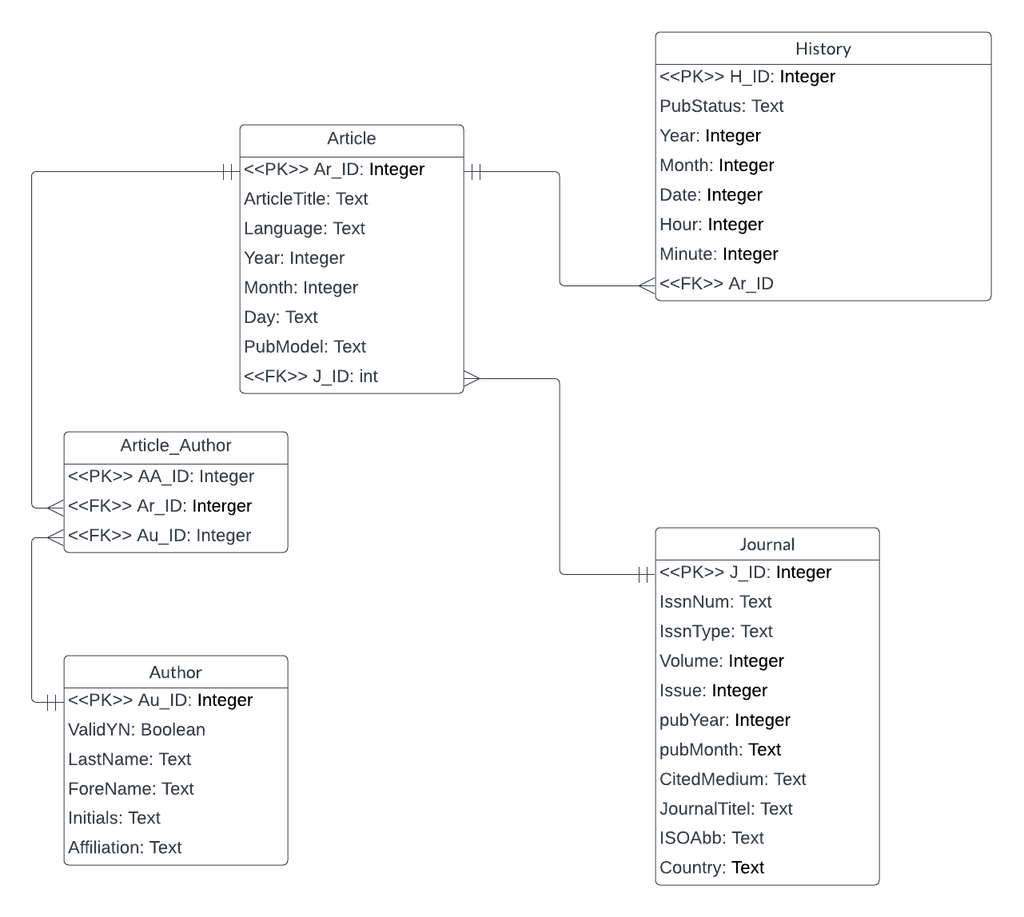

ERD part1

##Part1-2## #Realize the relational schema in SQLite ———————————————————————————–

```sql
DROP TABLE IF EXISTS History
```

```sql
DROP TABLE IF EXISTS Article_Author
```

```sql
DROP TABLE IF EXISTS Article
```

```sql
DROP TABLE IF EXISTS Author
```

```sql
DROP TABLE IF EXISTS Journal
```

```sql
CREATE TABLE IF NOT EXISTS Journal(
  j_ID INTEGER PRIMARY KEY AUTOINCREMENT,
  issnNum TEXT NOT NULL,
  issnType TEXT NOT NULL,
  volume INTEGER NOT NULL,
  issue INTEGER NOT NULL,
  pubYear INTEGER NOT NULL,
  pubMonth TEXT NOT NULL,
  citedMedium TEXT NOT NULL,
  jTitle TEXT NOT NULL,
  isoAbb TEXT NOT NULL,
  country TEXT NOT NULL
)
```

```sql
CREATE TABLE IF NOT EXISTS Article(
  ar_ID INTEGER PRIMARY KEY AUTOINCREMENT,
  aTitle TEXT NOT NULL,
  language TEXT NOT NULL,
  year INTEGER NOT NULL,
  month INTEGER NOT NULL,
  day TEXT NOT NULL,
  pubModel TEXT NOT NULL,
  j_ID INTEGER NOT NULL,
  FOREIGN KEY (j_ID) REFERENCES Journal(j_ID)
)
```

```sql
CREATE TABLE IF NOT EXISTS Author(
  au_ID INTEGER PRIMARY KEY AUTOINCREMENT,
  valid BOOLEAN NOT NULL,
  lastN TEXT NOT NULL,
  foreN TEXT NOT NULL,
  initials TEXT NOT NULL,
  affiliation TEXT NOT NULL
)
```

```sql
CREATE TABLE IF NOT EXISTS Article_Author(
  aa_ID INTEGER PRIMARY KEY AUTOINCREMENT,
  ar_ID INTEGER NOT NULL,
  au_ID INTEGER NOT NULL,
  FOREIGN KEY (ar_ID) REFERENCES Article(ar_ID),
  FOREIGN KEY (au_ID) REFERENCES Author(au_ID)
)
```

```sql
CREATE TABLE IF NOT EXISTS History(
  h_ID INTEGER PRIMARY KEY AUTOINCREMENT,
  pubStatus TEXT NOT NULL,
  hYear INTEGER NOT NULL,
  hMonth INTEGER NOT NULL,
  hDay INTEGER NOT NULL,
  hHour INTEGER NOT NULL,
  hMinute INTEGER NOT NULL,
  ar_ID INTEGER NOT NULL,
  FOREIGN KEY (ar_ID) REFERENCES Article(ar_ID)
)
```

##Part1-3## #Extract and transform the data from the XML and then load into the appropriate tables in the database. ———————————————————————————–

```r
library(XML)
path <- "/Users/MaisieGao/Downloads/databases/"
xmlN <- "pubmed_sample.xml"
xmlPath <- paste0(path, xmlN)

# Reading the XML file and parse into DOM
xmlDOM <- xmlParse(file = xmlPath)

# get the root node / size of the DOM tree
root <- xmlRoot(xmlDOM)
arNum <- xmlSize(root)
```

```r
for (i in 1:arNum){
  #the article node for this round
  pubArN = root[[i]]

  #article node, medlineJournalInfo node, history node
  arN <- pubArN[["MedlineCitation"]][["Article"]]
  mJourInfoN <- pubArN[["MedlineCitation"]][["MedlineJournalInfo"]]
  hisN <- pubArN[["PubmedData"]][["History"]]

  #========1) Parsing Journal===========
  jN <- arN[["Journal"]]

  issnNum <- xmlValue(jN[["ISSN"]])
  issnType <- xmlGetAttr(jN[["ISSN"]], "IssnType")
  volume <- xmlValue(jN[["JournalIssue"]][["Volume"]])
  issue <- xmlValue(jN[["JournalIssue"]][["Issue"]])

  #parsing date part:
  #two cases: Year + Month & MedlineDate
  pubYear <- xmlValue(jN[["JournalIssue"]][["PubDate"]][["Year"]])
  pubMonth <- xmlValue(jN[["JournalIssue"]][["PubDate"]][["Month"]])
  if(is.na(pubYear) ){
    date <- xmlValue(jN[["JournalIssue"]][["PubDate"]][["MedlineDate"]])
    splitD <- strsplit(date, split=" ")
    pubYear <- splitD[[1]][1]
    pubMonth <- splitD[[1]][2]
  }

  citedMedium <- xmlGetAttr(jN[["JournalIssue"]], "CitedMedium")
  jTitle <- xmlValue(jN[["Title"]])
  isoAbb <- xmlValue(jN[["ISOAbbreviation"]])
  country <- xmlValue(mJourInfoN[["Country"]])

  #check if the journal exists
  sql_jExi <- paste0("SELECT j_ID FROM Journal WHERE jTitle=\"", jTitle, "\" AND pubYear=\"", pubYear,"\" AND pubMonth=\"", pubMonth,"\";")
  j_ID <- dbGetQuery(dbcon, sql_jExi)[1,1]
  #if not, insert
  if(is.na(j_ID)){
    sqlInsJ <- paste0("INSERT INTO Journal(issnNum, issnType, volume, issue, pubYear, pubMonth, citedMedium, jTitle, isoAbb, country)
                   VALUES (\"", issnNum, "\",
                          \"", issnType, "\",
                          \"", volume, "\",
                          \"", issue, "\",
                          \"", pubYear, "\",
                          \"", pubMonth, "\",
                          \"", citedMedium, "\",
                          \"", jTitle, "\",
                          \"", isoAbb, "\",
                          \"", country, "\");")
    dbExecute(dbcon, sqlInsJ)
  }



  #========2) Parsing Article===========
  aTitle <- xmlValue(arN[["ArticleTitle"]])
  language <- xmlValue(arN[["Language"]])

  articleDate <- arN[["ArticleDate"]]
  year <- xmlValue(articleDate[["Year"]])
  if(is.na(year)){
      year <- -1
    }
  month <- xmlValue(articleDate[["Month"]])
  if(is.na(month)){
      month <- -1
    }
  day <- xmlValue(articleDate[["Day"]])
  if(is.na(day)){
      day <- -1
    }

  pubModel <- xmlGetAttr(arN, "PubModel")

  #get FK - j_ID
  sql_jIDtoA <- paste0("SELECT j_ID FROM Journal WHERE jTitle=\"", jTitle, "\" AND pubYear=\"", pubYear,"\" AND pubMonth=\"", pubMonth,"\";")
  j_ID <- dbGetQuery(dbcon, sql_jIDtoA)[1,1]

  #check if the article exists
  sql_aExi <- paste0("SELECT ar_ID FROM Article WHERE aTitle=\"", aTitle, "\" AND year=\"", year,"\" AND month=\"", month,"\" AND day=\"", day,"\";")
  ar_ID <- dbGetQuery(dbcon, sql_aExi)[1,1]
  #if not, insert
  if(is.na(ar_ID)){
    sqlInsAr <- paste0("INSERT INTO Article(aTitle, language, year, month, day, pubModel, j_ID)
                   VALUES (\"", aTitle, "\",
                          \"", language, "\",
                          \"", year, "\",
                          \"", month, "\",
                          \"", day, "\",
                          \"", pubModel, "\",
                          \"", j_ID, "\");")
    dbExecute(dbcon, sqlInsAr)
  }



  #========3) Parsing History===========
  hNum <- xmlSize(hisN)
  for (h in 1:hNum){
    curHisN <- hisN[[h]]

    pubStatus <- xmlGetAttr(curHisN, "PubStatus")
    hYear <- xmlValue(curHisN[["Year"]])
    hMonth <- xmlValue(curHisN[["Month"]])
    hDay <- xmlValue(curHisN[["Day"]])
    hHour <- xmlValue(curHisN[["Hour"]])
    if(is.na(hHour)){
      hHour <- -1
    }
    hMinute <- xmlValue(curHisN[["Minute"]])
    if(is.na(hMinute)){
      hMinute <- -1
    }

    #get FK - ar_ID
    sql_arIDtoH <- paste0("SELECT j_ID FROM Article WHERE aTitle=\"", aTitle, "\" AND year=\"", year,"\" AND month=\"", month,"\" AND day=\"", day,"\";")
    ar_ID <- dbGetQuery(dbcon, sql_arIDtoH)[1,1]

    sqlInsH <- paste0("INSERT INTO History(pubStatus, hYear, hMonth, hDay, hHour, hMinute, ar_ID)
                   VALUES (\"", pubStatus, "\",
                          \"", hYear, "\",
                          \"", hMonth, "\",
                          \"", hDay, "\",
                          \"", hHour, "\",
                          \"", hMinute, "\",
                          \"", ar_ID, "\");")
    dbExecute(dbcon, sqlInsH)
  }



  #========4) Parsing Author & Link Article/Author===========
  #Get ar_ID for this round
  sql_aExi <- paste0("SELECT ar_ID FROM Article WHERE aTitle=\"", aTitle, "\" AND year=\"", year,"\" AND month=\"", month,"\" AND day=\"", day,"\";")
  ar_ID <- dbGetQuery(dbcon, sql_aExi)[1,1]

  #===Parsing Author=====
  auListN <- arN[["AuthorList"]]
  auNum <- xmlSize(auListN)
  for (au in 1:auNum){
    curAuN <- auListN[[au]]

    validStr <- xmlGetAttr(curAuN, "ValidYN")
    if (validStr == "Y") {
      valid <- 1
    }else{
      valid <- 0
    }
    lastN <- xmlValue(curAuN[["LastName"]])
    foreN <- xmlValue(curAuN[["ForeName"]])
    initials <- xmlValue(curAuN[["Initials"]])
    affiliation <- xmlValue(curAuN[["Affiliation"]])

    #check if the author exists
    sql_auExi <- paste0("SELECT au_ID FROM Author WHERE lastN=\"", lastN, "\" AND valid=\"", valid, "\" AND foreN=\"",
                        foreN,"\" AND initials=\"", initials,"\" AND affiliation=\"", affiliation,"\";")
    au_ID <- dbGetQuery(dbcon, sql_auExi)[1,1]
    #if not, insert
    if(is.na(au_ID)){
      sqlInsAu <- paste0("INSERT INTO Author(valid, lastN, foreN, initials, affiliation)
                     VALUES (\"", valid, "\",
                            \"", lastN, "\",
                            \"", foreN, "\",
                            \"", initials, "\",
                            \"", affiliation, "\");")
      dbExecute(dbcon, sqlInsAu)
    }

    #===Link Article/Author=====
    #Get au_ID for this round
    sql_auExi <- paste0("SELECT au_ID FROM Author WHERE lastN=\"", lastN, "\" AND valid=\"", valid, "\" AND foreN=\"",
                        foreN,"\" AND initials=\"", initials,"\" AND affiliation=\"", affiliation,"\";")
    au_ID <- dbGetQuery(dbcon, sql_auExi)[1,1]

    #insert AA
    sqlInsAA <- paste0("INSERT INTO Article_Author(ar_ID, au_ID)
                     VALUES (\"", ar_ID, "\",
                            \"", au_ID, "\");")
    dbExecute(dbcon, sqlInsAA)
  }

}
```

```sql
SELECT * FROM Journal;
```

| j_ID | issnNum | issnType | volume | issue | pubYear | pubMonth | citedMedium | jTitle | isoAbb | country |
| --- | --- | --- | --- | --- | --- | --- | --- | --- | --- | --- |
| 1 | 1556-3316 | Print | 8 | 2 | 2012 | Jul | Print | HSS journal : the musculoskeletal journal of Hospital for Special Surgery | HSS J | United States |
| 2 | 1545-7206 | Electronic | 54 | 2 | 2013 | Mar-Apr | Internet | Psychosomatics | Psychosomatics | England |
| 3 | 1524-4628 | Electronic | 43 | 11 | 2012 | Nov | Internet | Stroke; a journal of cerebral circulation | Stroke | United States |
| 4 | 1532-8651 | Electronic | 37 | 6 | 2012 | Nov-Dec | Internet | Regional anesthesia and pain medicine | Reg Anesth Pain Med | United States |
| 5 | 1532-2688 | Electronic | 22 | 1 | 2013 | Jan | Internet | Seizure : the journal of the British Epilepsy Association | Seizure | England |
| 6 | 1528-1132 | Electronic | 471 | 1 | 2013 | Jan | Internet | Clinical orthopaedics and related research | Clin. Orthop. Relat. Res. | United States |
| 7 | 1532-8406 | Electronic | 27 | 10 | 2012 | Dec | Internet | The Journal of arthroplasty | J Arthroplasty | United States |
| 8 | 1528-1175 | Electronic | 117 | 1 | 2012 | Jul | Internet | Anesthesiology | Anesthesiology | United States |
| 9 | 1432-1998 | Electronic | 42 | 8 | 2012 | Aug | Internet | Pediatric radiology | Pediatr Radiol | Germany |
| 10 | 1530-0358 | Electronic | 55 | 4 | 2012 | Apr | Internet | Diseases of the colon and rectum | Dis. Colon Rectum | United States |

[output cut: 9 more lines]

```sql
SELECT * FROM Article;
```

| ar_ID | aTitle | language | year | month | day | pubModel | j_ID |
| --- | --- | --- | --- | --- | --- | --- | --- |
| 1 | Regional anesthesia for children undergoing orthopedic ambulatory surgeries in the United States, 1996-2006. | eng | 2012 | 6 | 20 | Print-Electronic | 1 |
| 2 | Demographics and perioperative outcome in patients with depression and anxiety undergoing total joint arthroplasty: a population-based study. | eng | 2012 | 11 | 27 | Print-Electronic | 2 |
| 3 | Cerebrovascular reserve and stroke risk in patients with carotid stenosis or occlusion: a systematic review and meta-analysis. | eng | -1 | -1 | -1 | Print | 3 |
| 4 | Comparative perioperative outcomes associated with neuraxial versus general anesthesia for simultaneous bilateral total knee arthroplasty. | eng | -1 | -1 | -1 | Print | 4 |
| 5 | Vagus nerve stimulation vs. corpus callosotomy in the treatment of Lennox-Gastaut syndrome: a meta-analysis. | eng | 2012 | 10 | 12 | Print-Electronic | 5 |
| 6 | Have bilateral total knee arthroplasties become safer? A population-based trend analysis. | eng | 2012 | 9 | 25 | Print-Electronic | 6 |
| 7 | The metabolic syndrome in patients undergoing knee and hip arthroplasty: trends and in-hospital outcomes in the United States. | eng | 2012 | 6 | 05 | Print-Electronic | 7 |
| 8 | Utilization of critical care services among patients undergoing total hip and knee arthroplasty: epidemiology and risk factors. | eng | -1 | -1 | -1 | Print | 8 |
| 9 | Visualization of the normal appendix with MR enterography in children. | eng | 2012 | 3 | 21 | Print-Electronic | 9 |
| 10 | FDG-PET assessment of rectal cancer response to neoadjuvant chemoradiotherapy is not associated with long-term prognosis: a prospective evaluation. | eng | -1 | -1 | -1 | Print | 10 |

[output cut: 9 more lines]

```sql
SELECT * FROM History;
```

| h_ID | pubStatus | hYear | hMonth | hDay | hHour | hMinute | ar_ID |
| --- | --- | --- | --- | --- | --- | --- | --- |
| 1 | received | 2012 | 1 | 15 | -1 | -1 | 1 |
| 2 | accepted | 2012 | 4 | 16 | -1 | -1 | 1 |
| 3 | epublish | 2012 | 6 | 20 | -1 | -1 | 1 |
| 4 | entrez | 2013 | 7 | 23 | 6 | 0 | 1 |
| 5 | pubmed | 2013 | 7 | 23 | 6 | 0 | 1 |
| 6 | medline | 2013 | 7 | 23 | 6 | 1 | 1 |
| 7 | received | 2012 | 7 | 16 | -1 | -1 | 2 |
| 8 | revised | 2012 | 8 | 17 | -1 | -1 | 2 |
| 9 | accepted | 2012 | 8 | 20 | -1 | -1 | 2 |
| 10 | aheadofprint | 2012 | 11 | 27 | -1 | -1 | 2 |

[output cut: 84 more lines]

```sql
SELECT * FROM Author;
```

| au_ID | valid | lastN | foreN | initials | affiliation |
| --- | --- | --- | --- | --- | --- |
| 1 | 1 | Kuo | Cassie | C | Department of Anesthesiology, Hospital for Special Surgery, 535 East 70th Street, New York, NY 10021 USA. |
| 2 | 1 | Edwards | Alison | A | NA |
| 3 | 1 | Mazumdar | Madhu | M | NA |
| 4 | 1 | Memtsoudis | Stavros G | SG | NA |
| 5 | 1 | Stundner | Ottokar | O | Department of Anesthesiology, Hospital for Special Surgery, Weill Medical College of Cornell University, New York, NY, USA. |
| 6 | 1 | Kirksey | Meghan | M | NA |
| 7 | 1 | Chiu | Ya Lin | YL | NA |
| 8 | 1 | Poultsides | Lazaros | L | NA |
| 9 | 1 | Gerner | Peter | P | NA |
| 10 | 1 | Gupta | Ajay | A | Department of Radiology, Weill Cornell Medical School, New York-Presbyterian Hospital, 525 East 68th Street, Starr 8A, Box 141, New York, NY 10065, USA. ajg9004@med.cornell.edu |

[output cut: 82 more lines]

```sql
SELECT * FROM Article_Author;
```

| aa_ID | ar_ID | au_ID |
| --- | --- | --- |
| 1 | 1 | 1 |
| 2 | 1 | 2 |
| 3 | 1 | 3 |
| 4 | 1 | 4 |
| 5 | 2 | 5 |
| 6 | 2 | 6 |
| 7 | 2 | 7 |
| 8 | 2 | 3 |
| 9 | 2 | 8 |
| 10 | 2 | 9 |

[output cut: 126 more lines]

## ##Part2-1##

#The ERD for part2-1 of the practicum

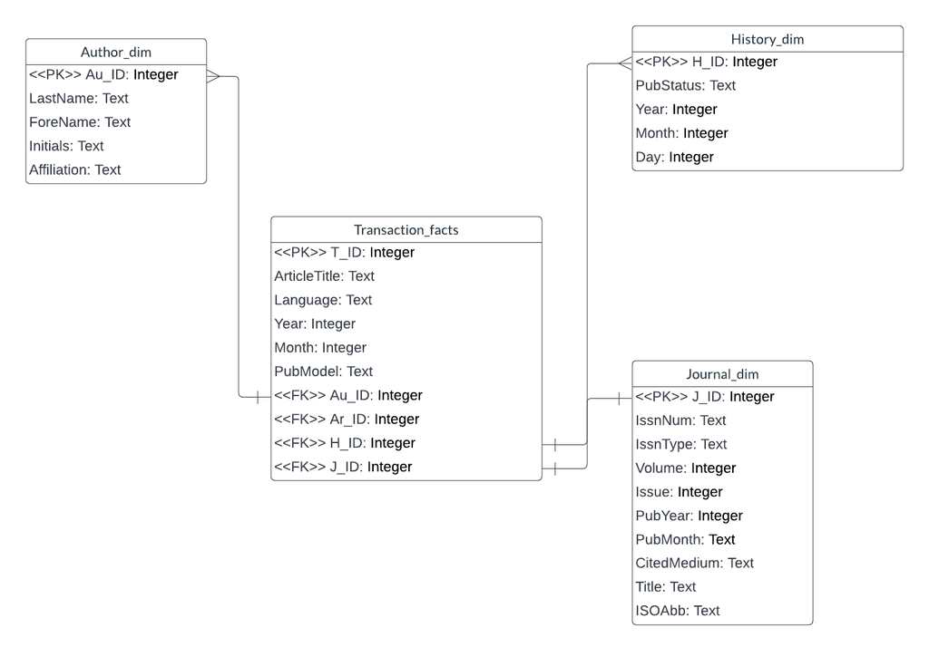

#Realize the star schema in SQLite

#Drop all the tables if they existed

```sql
DROP TABLE IF EXISTS Summary_facts
```

```sql
DROP TABLE IF EXISTS Transaction_facts
```

```sql
DROP TABLE IF EXISTS Author_dim
```

```sql
DROP TABLE IF EXISTS History_dim
```

```sql
DROP TABLE IF EXISTS Article_dim;
```

#Create Author_dim table

```sql
CREATE TABLE Author_dim(
  au_ID INTEGER PRIMARY KEY,
  lastN TEXT NOT NULL,
  foreN TEXT NOT NULL,
  initials TEXT NOT NULL,
  affiliation TEXT NOT NULL
)
```

#Create History_dim table

```sql
CREATE TABLE History_dim(
  h_ID INTEGER PRIMARY KEY,
  pubStatus TEXT NOT NULL,
  hYear INTEGER NOT NULL,
  hMonth INTEGER NOT NULL,
  hDay INTEGER NOT NULL
)
```

#Create Journal_dim table

```sql
CREATE TABLE Journal_dim(
  j_ID INTEGER PRIMARY KEY,
  issnNum TEXT NOT NULL,
  issnType TEXT NOT NULL,
  volume INTEGER NOT NULL,
  issue INTEGER NOT NULL,
  pubYear INTEGER NOT NULL,
  pubMonth TEXT NOT NULL,
  citedMedium TEXT NOT NULL,
  jTitle TEXT NOT NULL,
  isoAbb TEXT NOT NULL
)
```

#Create Transaction_facts table

```sql
CREATE TABLE Transaction_facts(
  t_ID INTEGER PRIMARY KEY AUTOINCREMENT,
  aTitle TEXT NOT NULL,
  language TEXT NOT NULL,
  year INTEGER NOT NULL,
  month INTEGER NOT NULL,
  pubModel TEXT NOT NULL,
  au_ID INTEGER NOT NULL,
  ar_ID INTEGER NOT NULL,
  h_ID INTEGER NOT NULL,
  j_ID INTEGER NOT NULL,
  FOREIGN KEY (au_ID) REFERENCES Author_dim(au_ID),
  FOREIGN KEY (ar_ID) REFERENCES Article_dim(ar_ID),
  FOREIGN KEY (h_ID) REFERENCES History_dim(h_ID),
  FOREIGN KEY (j_ID) REFERENCES Journal_dim(j_ID)
)
```

#Insert data into Author_dim

```r
statement1 <- 'INSERT INTO Author_dim(au_ID, lastN, foreN, initials, affiliation)
SELECT au_ID, lastN, foreN, initials, affiliation
FROM Author;'
dbExecute(dbcon, statement1)
```

```
[1] 92
```

```sql
SELECT * FROM Author_dim;
```

| au_ID | lastN | foreN | initials | affiliation |
| --- | --- | --- | --- | --- |
| 1 | Kuo | Cassie | C | Department of Anesthesiology, Hospital for Special Surgery, 535 East 70th Street, New York, NY 10021 USA. |
| 2 | Edwards | Alison | A | NA |
| 3 | Mazumdar | Madhu | M | NA |
| 4 | Memtsoudis | Stavros G | SG | NA |
| 5 | Stundner | Ottokar | O | Department of Anesthesiology, Hospital for Special Surgery, Weill Medical College of Cornell University, New York, NY, USA. |
| 6 | Kirksey | Meghan | M | NA |
| 7 | Chiu | Ya Lin | YL | NA |
| 8 | Poultsides | Lazaros | L | NA |
| 9 | Gerner | Peter | P | NA |
| 10 | Gupta | Ajay | A | Department of Radiology, Weill Cornell Medical School, New York-Presbyterian Hospital, 525 East 68th Street, Starr 8A, Box 141, New York, NY 10065, USA. ajg9004@med.cornell.edu |

[output cut: 82 more lines]

#Insert data into History_dim

```r
statement2 <- 'INSERT INTO History_dim(h_ID, pubStatus, hYear, hMonth, hDay)
SELECT h_ID, pubStatus, hYear, hMonth, hDay
FROM History;'
dbExecute(dbcon, statement2)
```

```
[1] 94
```

```sql
SELECT * FROM History_dim;
```

| h_ID | pubStatus | hYear | hMonth | hDay |
| --- | --- | --- | --- | --- |
| 1 | received | 2012 | 1 | 15 |
| 2 | accepted | 2012 | 4 | 16 |
| 3 | epublish | 2012 | 6 | 20 |
| 4 | entrez | 2013 | 7 | 23 |
| 5 | pubmed | 2013 | 7 | 23 |
| 6 | medline | 2013 | 7 | 23 |
| 7 | received | 2012 | 7 | 16 |
| 8 | revised | 2012 | 8 | 17 |
| 9 | accepted | 2012 | 8 | 20 |
| 10 | aheadofprint | 2012 | 11 | 27 |

[output cut: 84 more lines]

#Insert data into Journal_dim

```r
statement4 <- 'INSERT INTO Journal_dim(j_ID, issnNum, issnType, volume, issue, pubYear, pubMonth, citedMedium, jTitle, isoAbb)
SELECT j_ID, issnNum, issnType, volume, issue, pubYear, pubMonth, citedMedium, jTitle, isoAbb
FROM Journal;'
dbExecute(dbcon, statement4)
```

```
[1] 19
```

```sql
SELECT * FROM Journal_dim;
```

| j_ID | issnNum | issnType | volume | issue | pubYear | pubMonth | citedMedium | jTitle | isoAbb |
| --- | --- | --- | --- | --- | --- | --- | --- | --- | --- |
| 1 | 1556-3316 | Print | 8 | 2 | 2012 | Jul | Print | HSS journal : the musculoskeletal journal of Hospital for Special Surgery | HSS J |
| 2 | 1545-7206 | Electronic | 54 | 2 | 2013 | Mar-Apr | Internet | Psychosomatics | Psychosomatics |
| 3 | 1524-4628 | Electronic | 43 | 11 | 2012 | Nov | Internet | Stroke; a journal of cerebral circulation | Stroke |
| 4 | 1532-8651 | Electronic | 37 | 6 | 2012 | Nov-Dec | Internet | Regional anesthesia and pain medicine | Reg Anesth Pain Med |
| 5 | 1532-2688 | Electronic | 22 | 1 | 2013 | Jan | Internet | Seizure : the journal of the British Epilepsy Association | Seizure |
| 6 | 1528-1132 | Electronic | 471 | 1 | 2013 | Jan | Internet | Clinical orthopaedics and related research | Clin. Orthop. Relat. Res. |
| 7 | 1532-8406 | Electronic | 27 | 10 | 2012 | Dec | Internet | The Journal of arthroplasty | J Arthroplasty |
| 8 | 1528-1175 | Electronic | 117 | 1 | 2012 | Jul | Internet | Anesthesiology | Anesthesiology |
| 9 | 1432-1998 | Electronic | 42 | 8 | 2012 | Aug | Internet | Pediatric radiology | Pediatr Radiol |
| 10 | 1530-0358 | Electronic | 55 | 4 | 2012 | Apr | Internet | Diseases of the colon and rectum | Dis. Colon Rectum |

[output cut: 9 more lines]

#Insert data into Transaction_facts

```r
statement5 <- 'INSERT INTO Transaction_facts(aTitle, language, year,month,pubModel,ar_ID,j_ID,h_ID,au_ID)
SELECT Article.aTitle, Article.language, Article.year,Article.month,Article.pubModel,Article.ar_ID,Journal.j_ID,History.h_ID,Article_Author.au_ID
FROM Article
LEFT JOIN Journal
USING(j_ID)
LEFT JOIN History
USING(ar_ID)
RIGHT JOIN Article_Author
USING(ar_ID)
;'
dbExecute(dbcon, statement5)
```

```
[1] 661
```

```sql
SELECT * FROM Transaction_facts;
```

| t_ID | aTitle | language | year | month | pubModel | au_ID | ar_ID | h_ID | j_ID |
| --- | --- | --- | --- | --- | --- | --- | --- | --- | --- |
| 1 | Regional anesthesia for children undergoing orthopedic ambulatory surgeries in the United States, 1996-2006. | eng | 2012 | 6 | Print-Electronic | 1 | 1 | 1 | 1 |
| 2 | Regional anesthesia for children undergoing orthopedic ambulatory surgeries in the United States, 1996-2006. | eng | 2012 | 6 | Print-Electronic | 2 | 1 | 1 | 1 |
| 3 | Regional anesthesia for children undergoing orthopedic ambulatory surgeries in the United States, 1996-2006. | eng | 2012 | 6 | Print-Electronic | 3 | 1 | 1 | 1 |
| 4 | Regional anesthesia for children undergoing orthopedic ambulatory surgeries in the United States, 1996-2006. | eng | 2012 | 6 | Print-Electronic | 4 | 1 | 1 | 1 |
| 5 | Regional anesthesia for children undergoing orthopedic ambulatory surgeries in the United States, 1996-2006. | eng | 2012 | 6 | Print-Electronic | 1 | 1 | 2 | 1 |
| 6 | Regional anesthesia for children undergoing orthopedic ambulatory surgeries in the United States, 1996-2006. | eng | 2012 | 6 | Print-Electronic | 2 | 1 | 2 | 1 |
| 7 | Regional anesthesia for children undergoing orthopedic ambulatory surgeries in the United States, 1996-2006. | eng | 2012 | 6 | Print-Electronic | 3 | 1 | 2 | 1 |
| 8 | Regional anesthesia for children undergoing orthopedic ambulatory surgeries in the United States, 1996-2006. | eng | 2012 | 6 | Print-Electronic | 4 | 1 | 2 | 1 |
| 9 | Regional anesthesia for children undergoing orthopedic ambulatory surgeries in the United States, 1996-2006. | eng | 2012 | 6 | Print-Electronic | 1 | 1 | 3 | 1 |
| 10 | Regional anesthesia for children undergoing orthopedic ambulatory surgeries in the United States, 1996-2006. | eng | 2012 | 6 | Print-Electronic | 2 | 1 | 3 | 1 |

[output cut: 651 more lines]